# Practical 2

Xu Xiao S3612406

11/9/2018

## Part A

### 1. Open Data

#### 1a

```r
Practical1 <- readRDS(file="Practical1.rds")
#Practical1 <- read.csv(file="Practical1.csv")
```

### 2. First calculations: descriptive statistics

#### 2b

```r
table(Practical1$age)
```

```
##
## 14 15 16 17 18 19 20 21 22 23 24 25 26 27
##  1  1  3  2  3  1  3  3  3  2  3  2  1  1
```

16, 18, 20, 21, 22 and 24 are the most common ages in our dataset, all accured 3 times.

### 3. More descriptives: exploring frequencies

#### 3a

##### Mean

```r
mean(Practical1$profsc)
```

```
## [1] 69.13793
```

##### Median

```r
median(Practical1$profsc)
```

```
## [1] 68
```

##### Mode

```r
which.max(tabulate(Practical1$profsc))
```

```
## [1] 59
```

##### Standard deviation

```r
sd(Practical1$profsc)
```

```
## [1] 16.53508
```

#### 3b

```r
min(Practical1$profsc)
```

```
## [1] 33
```

##### Maximum age

```r
max(Practical1$age)
```

```
## [1] 27
```

```r
mean(Practical1$profsc)
```

```
## [1] 69.13793
```

##### Standard deviation of ages

```r
sd(Practical1$age)
```

```
## [1] 3.5317
```

#### 3c

```r
which.max(tabulate(Practical1$profsc))
```

```
## [1] 59
```

The most frequently occurring proficiency score is 59.

### 4. Getting to know the data: realationships

#### 4a/4b

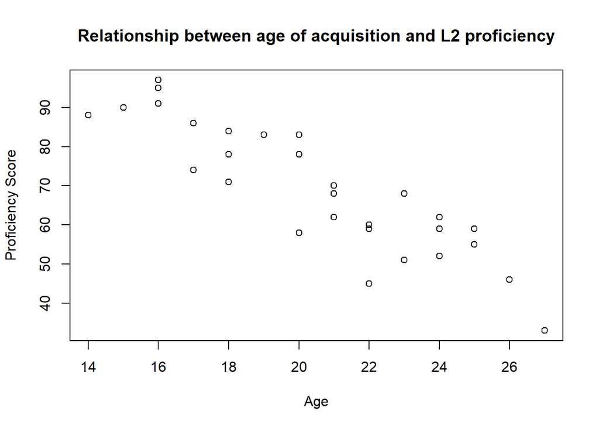

Figure 1. Scatterplot showing the relationship between Age of Acquisition and Proficiency.

```r
plot(Practical1$age, Practical1$profsc, xlab="Age",ylab="Proficiency Score", main="Relationship between age of acquisition and L2 proficiency")
```

#### 4c

Yes, from my point of view those two variables are negatively correlated.

### 5. Getting to know the data: comparing groups

#### 5a

```r
aggregate(profsc~gender, Practical1, mean)
```

```
##   gender   profsc
## 1 Female 75.53333
## 2   Male 62.28571
```

```r
aggregate(profsc~gender, Practical1, median)
```

```
##   gender profsc
## 1 Female   78.0
## 2   Male   59.5
```

```r
aggregate(profsc~gender, Practical1, range)
```

```
##   gender profsc.1 profsc.2
## 1 Female       52       97
## 2   Male       33       88
```

```r
aggregate(profsc~gender, Practical1, sd)
```

```
##   gender   profsc
## 1 Female 14.24212
## 2   Male 16.51307
```

#### 5b

Female participants have higner average and median proficiency scores.

#### 5c

The standard deviation of female participants’ proficiency score 14.24212, lower than 16.51307 from the male group. Thus we can say the female group scored more homogeneously.

#### 5d

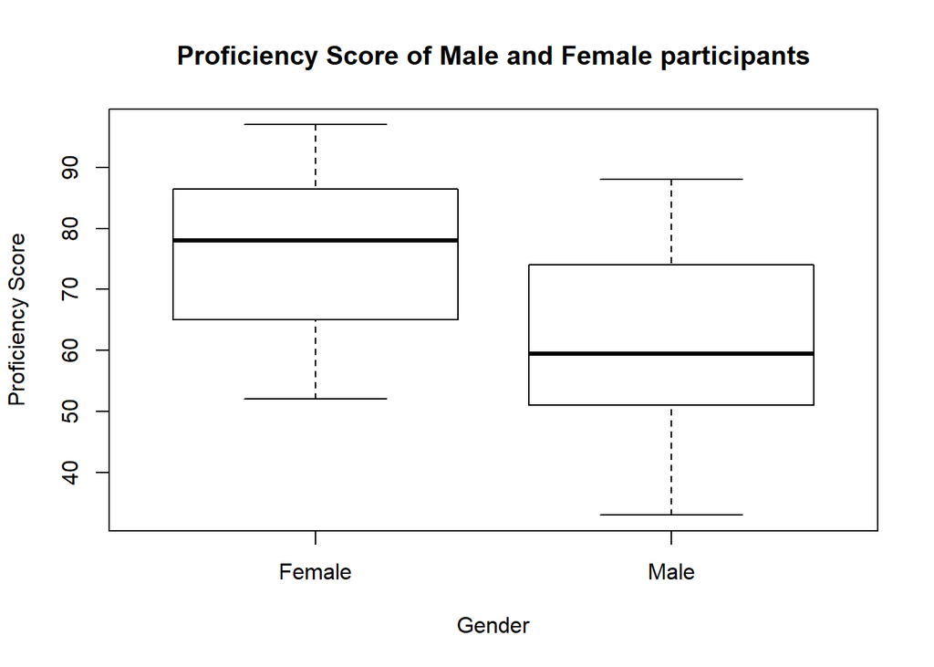

Figure 2. Box Plot showing the difference between male and female participants.

```r
boxplot(profsc ~ gender , data=Practical1, main="Proficiency Score of Male and Female participants", xlab="Gender", ylab="Proficiency Score")
```

#### 5e

The boxplot shows quartiles of the data. The first and third quartiles are shown as upper and lower “side” of the box and the second quartile (which is also the median) is drawn in the box.

## Part B

#### 1a

```r
a = c(3, 4, 5, 6, 7, 8, 9)
b = c(6, 6, 6, 6, 6, 6, 6)
c = c(4, 4, 4, 6, 7, 7, 10)
d = c(1, 1, 1, 4, 9, 12, 14)
```

```r
library("psych")
describe(Practical1$profsc)
```

```
##    vars  n  mean    sd median trimmed   mad min max range skew kurtosis
## X1    1 29 69.14 16.54     68    69.4 19.27  33  97    64 -0.1    -0.95
##      se
## X1 3.07
```

```r
describe(a)
```

```
##    vars n mean   sd median trimmed  mad min max range skew kurtosis   se
## X1    1 7    6 2.16      6       6 2.97   3   9     6    0    -1.71 0.82
```

```r
describe(b)
```

```
##    vars n mean sd median trimmed mad min max range skew kurtosis se
## X1    1 7    6  0      6       6   0   6   6     0  NaN      NaN  0
```

```r
describe(c)
```

```
##    vars n mean   sd median trimmed  mad min max range skew kurtosis   se
## X1    1 7    6 2.24      6       6 2.97   4  10     6 0.54    -1.25 0.85
```

```r
describe(d)
```

```
##    vars n mean  sd median trimmed  mad min max range skew kurtosis   se
## X1    1 7    6 5.6      4       6 4.45   1  14    13  0.3    -1.93 2.12
```

```r
which.max(tabulate(a))
```

```
## [1] 3
```

```r
which.max(tabulate(b))
```

```
## [1] 6
```

```r
which.max(tabulate(c))
```

```
## [1] 4
```

```r
which.max(tabulate(d))
```

```
## [1] 1
```

#### 1b

When there are multiple maximum values, R would only pick one from them. If we need all the maximum values we should use other functions.

## Part C

### 1. Load the file into R

#### 1a

```r
Practical2 <- read.csv("Data-Practical2C.csv", head=TRUE, sep=";")
str(Practical2)
```

```
## 'data.frame':    5200 obs. of  5 variables:
##  $ Subject    : int  1 2 3 4 5 6 7 8 9 10 ...
##  $ Motivation : int  5 3 1 2 2 2 1 5 4 3 ...
##  $ Proficiency: int  72 28 26 23 76 40 57 24 89 72 ...
##  $ Education  : int  1 3 4 2 3 3 2 1 3 3 ...
##  $ Internet   : int  0 0 0 0 0 1 0 0 0 1 ...
```

```r
Practical2$Motivation <- as.ordered(Practical2$Motivation)
Practical2$Motivation <- ordered(Practical2$Motivation,
                                 levels=c(1,2,3,4,5),
                                 labels=c("very low", "low", "neutral", "high", "very high"))
Practical2$Education <- as.ordered(Practical2$Education)
Practical2$Education <- ordered(Practical2$Education,
                                levels=c(1,2,3,4,5),
                                labels=c("did not complete high school", "high school degree", "some college", "college degree", "post-undergraduate"))
Practical2$Internet <- as.factor(Practical2$Internet)
Practical2$Internet <- factor(Practical2$Internet,
                              levels=c(0,1,8,9),
                              labels=c("no", "yes", "does not know", "no answer"))

str(Practical2)
```

```
## 'data.frame':    5200 obs. of  5 variables:
##  $ Subject    : int  1 2 3 4 5 6 7 8 9 10 ...
##  $ Motivation : Ord.factor w/ 5 levels "very low"<"low"<..: 5 3 1 2 2 2 1 5 4 3 ...
##  $ Proficiency: int  72 28 26 23 76 40 57 24 89 72 ...
##  $ Education  : Ord.factor w/ 5 levels "did not complete high school"<..: 1 3 4 2 3 3 2 1 3 3 ...
##  $ Internet   : Factor w/ 4 levels "no","yes","does not know",..: 1 1 1 1 1 2 1 1 1 2 ...
```

#### 1b

```r
saveRDS(Practical2, file="Practical2.rds")
Practical2 <- readRDS("Practical2.rds")
str(Practical2)
```

```
## 'data.frame':    5200 obs. of  5 variables:
##  $ Subject    : int  1 2 3 4 5 6 7 8 9 10 ...
##  $ Motivation : Ord.factor w/ 5 levels "very low"<"low"<..: 5 3 1 2 2 2 1 5 4 3 ...
##  $ Proficiency: int  72 28 26 23 76 40 57 24 89 72 ...
##  $ Education  : Ord.factor w/ 5 levels "did not complete high school"<..: 1 3 4 2 3 3 2 1 3 3 ...
##  $ Internet   : Factor w/ 4 levels "no","yes","does not know",..: 1 1 1 1 1 2 1 1 1 2 ...
```

### 2. Descriptive statistics

#### 2a

```r
describe(Practical2$Proficiency)
```

```
##    vars    n  mean    sd median trimmed   mad min max range skew kurtosis
## X1    1 5200 42.17 21.19     37   40.09 20.76   9  98    89 0.76    -0.25
##      se
## X1 0.29
```

```r
aggregate(Proficiency~Motivation, Practical2, mean)
```

```
##   Motivation Proficiency
## 1   very low    34.23128
## 2        low    39.50173
## 3    neutral    42.44178
## 4       high    46.52830
## 5  very high    50.71035
```

```r
aggregate(Proficiency~Motivation, Practical2, median)
```

```
##   Motivation Proficiency
## 1   very low          30
## 2        low          34
## 3    neutral          37
## 4       high          42
## 5  very high          49
```

```r
aggregate(Proficiency~Motivation, Practical2, range)
```

```
##   Motivation Proficiency.1 Proficiency.2
## 1   very low             9            97
## 2        low             9            98
## 3    neutral             9            98
## 4       high             9            98
## 5  very high             9            98
```

```r
aggregate(Proficiency~Motivation, Practical2, sd)
```

```
##   Motivation Proficiency
## 1   very low    16.89581
## 2        low    19.96060
## 3    neutral    21.05699
## 4       high    21.84818
## 5  very high    22.94467
```

```r
which.max(tabulate(Practical2$Proficiency))
```

```
## [1] 25
```

```r
which.max(tabulate(Practical2$Proficiency[Practical2$Motivation =='very low']))
```

```
## [1] 19
```

```r
which.max(tabulate(Practical2$Proficiency[Practical2$Motivation =='low']))
```

```
## [1] 24
```

```r
which.max(tabulate(Practical2$Proficiency[Practical2$Motivation =='neutral']))
```

```
## [1] 28
```

```r
which.max(tabulate(Practical2$Proficiency[Practical2$Motivation =='high']))
```

```
## [1] 29
```

```r
which.max(tabulate(Practical2$Proficiency[Practical2$Motivation =='very high']))
```

```
## [1] 36
```

Figure 3. Table shows reports of proficiency score from different motivation groups.

| value | Overall | very low | low | neutral | high | very high |
| --- | --- | --- | --- | --- | --- | --- |
| mean | 42.17 | 34.23 | 39.50 | 42.44 | 46.53 | 50.71 |
| mode | 25 | 19 | 24 | 28 | 29 | 36 |
| median | 37 | 30 | 34 | 37 | 42 | 49 |
| sd | 21.19 | 16.90 | 19.96 | 21.06 | 21.85 | 22.94 |

#### 2b

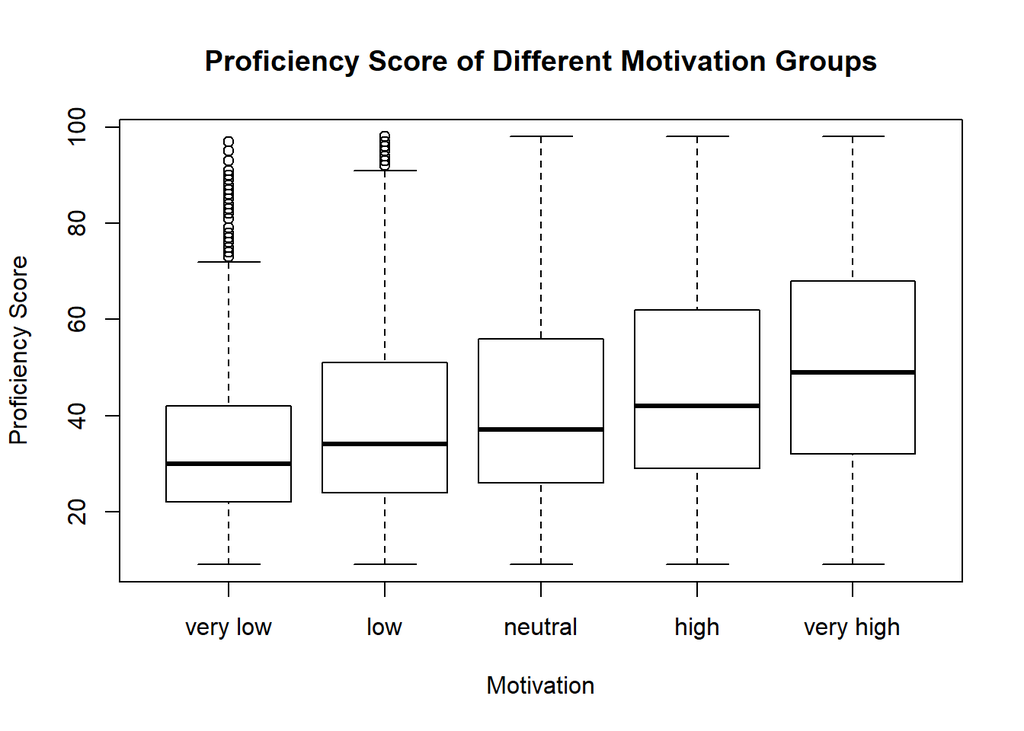

Figure 4. Box Plot showing the difference between different motivation groups.

```r
boxplot(Proficiency ~ Motivation , data=Practical2, main="Proficiency Score of Different Motivation Groups", xlab="Motivation", ylab="Proficiency Score")
```

Each group differs from each other in proficiency score; from motivation level “very low” to “very high”, every quartile is increasing, means that general proficiency score increses with motivation.

### 3. Checking the normal distribution

#### 3a

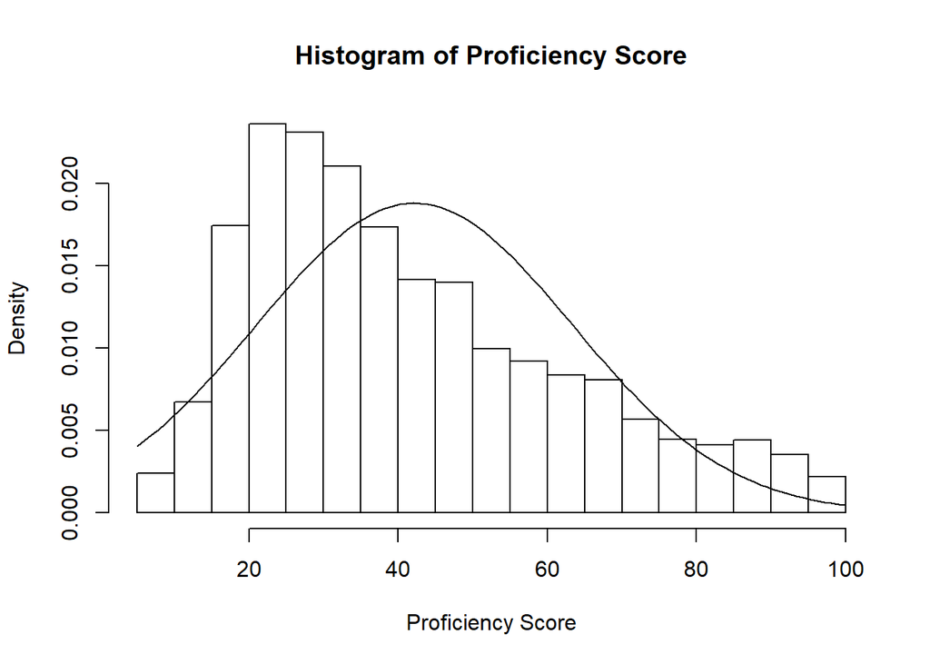

Figure 5. Histogram showing the distribution of proficiency scores.

```r
hist(Practical2$Proficiency, prob=TRUE, xlab="Proficiency Score", main="Histogram of Proficiency Score")
curve(dnorm(x, mean=mean(Practical2$Proficiency), sd=sd(Practical2$Proficiency)), add=TRUE)
```

#### 3b

```r
describe(Practical2$Proficiency)
```

```
##    vars    n  mean    sd median trimmed   mad min max range skew kurtosis
## X1    1 5200 42.17 21.19     37   40.09 20.76   9  98    89 0.76    -0.25
##      se
## X1 0.29
```

#### 3c